# Giblin.Kealalani.AdvancedAssignment2

Kealalani Giblin

2025-11-05

INITIALISATION: 1. Use initial rough values of Ta0 = 240 K, αc =0.01 K-1, αo =0.3, εac = 0.01 K-1 and εao = 0.78 to plot (using R) how atmospheric and surface temperature vary through a 20-year period. Do the values converge to an asymptote? If so, comment on how the values compare with the model from Section 6.8 (with constant emissivity and albedo).

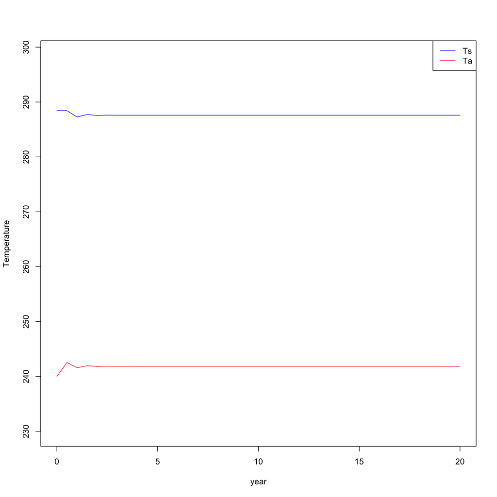

```r
simulateClimateChange <- function(plot_flag = TRUE) {
A <- 4 * pi * (6378000^2) #earths surface area
propn_ocean <- 0.7 #proportion of earths surface = ocean
C <- (A * propn_ocean * 100 * 1025 *3.993) + (A * (1 - propn_ocean) * 5 * 1600 * 0.8) #earths heat capacity

S <- 1368 #solar constant
sigma <- 5.6704e-8 #S-B constant
Ta0 <- 240 #ref atmospheric temp
alpha_c <- 0.01 #albedo variation coefficient
alpha_0 <- 0.3 #ref albedo
eps_ac <- 0.01 #emssivity variation coefficient
eps_a0 <- 0.78 #ref emissivity

time_int <- (365 / 2) * 24 * 60 * 60 #time interval (secs in a half year)
num_years <- 20 #years to run the simulation for

year <- seq(from = 0, to = 20, by = 0.5)
rate_in <- rep(S/4, length(year))
rate_out <- numeric(length(year))
delta_T <- numeric(length(year))
Ts <- numeric(length(year))
Ts[1] <- ((S * (1 - alpha_0)) / (4 * sigma * (1 - (eps_a0 / 2)))) ^ 0.25
Ta <- numeric(length(year))
Ta[1] <- Ta0
alpha <- numeric(length(year))
alpha[1] <- alpha_0
epsilon_a <- numeric(length(year))
epsilon_a[1] <- eps_a0

for (i in 2:length(year)) {
  epsilon_a[i] <- eps_ac * (Ta[i-1] - Ta0) + eps_a0
  alpha[i] <- alpha_c * (Ta[i-1] - Ta0) + alpha_0

  Ts[i] <- ((S * (1 - alpha[i])) / (4 * sigma * (1 - (epsilon_a[i] / 2)))) ^ 0.25
  Ta[i] = Ts[i] / (2 ^ 0.25)

  rate_out[i] = alpha[i] * S / 4 + (1 - epsilon_a[i]) * sigma * Ts[i]^4 + epsilon_a[i] * sigma * Ta[i]^4

  delta_T[i] = (1 / C) * (rate_in[i] - rate_out[i]) * (A / 1000) * time_int

  if (i < length(year)) {
        Ts[i+1] = Ts[i] + delta_T[i]
        } else {}
}

ClimateChange <- data.frame(year, rate_in, rate_out, delta_T, Ts, Ta)

plot_flag <- TRUE

if (plot_flag){
  with(ClimateChange, plot(Ts ~ year, type = "l", col = "blue", ylim = c(min(Ta) - 10, max(Ts)+10), ylab = "Temperature"))
  lines(Ta ~ year, type = "l", col = "red")
  legend("topright", c("Ts", "Ta"), lty = c(1, 1), col = c("blue", "red"))
}

return(ClimateChange)
}

result <- simulateClimateChange(plot_flag = TRUE)
```

Yes, the atmospheric temperature converges to an asymptote around 242 K and the surface temperature converges to an asymptote around 287 K. This is around the same values as the model in section 6.8 (Figure 6.8-4).

```r
simulateClimateChange <- function(alpha_c = 0.01, eps_ac = 0.01, plot_flag = TRUE) {
  A <- 4 * pi * (6378000^2) # earth surface area
  propn_ocean <- 0.7
  C <- (A * propn_ocean * 100 * 1025 * 3.993) + (A * (1 - propn_ocean) * 5 * 1600 * 0.8)

  S <- 1368
  sigma <- 5.6704e-8
  Ta0 <- 240
  alpha_0 <- 0.3
  eps_a0 <- 0.78

  time_int <- (365 / 2) * 24 * 60 * 60
  num_years <- 20
  year <- seq(from = 0, to = num_years, by = 0.5)

  rate_in <- rep(S / 4, length(year))
  rate_out <- numeric(length(year))
  delta_T <- numeric(length(year))
  Ts <- numeric(length(year))
  Ts[1] <- ((S * (1 - alpha_0)) / (4 * sigma * (1 - (eps_a0 / 2)))) ^ 0.25
  Ta <- numeric(length(year))
  Ta[1] <- Ta0
  alpha <- numeric(length(year))
  alpha[1] <- alpha_0
  epsilon_a <- numeric(length(year))
  epsilon_a[1] <- eps_a0

  for (i in 2:length(year)) {
    epsilon_a[i] <- eps_ac * (Ta[i-1] - Ta0) + eps_a0
    alpha[i] <- alpha_c * (Ta[i-1] - Ta0) + alpha_0

    Ts[i] <- ((S * (1 - alpha[i])) / (4 * sigma * (1 - (epsilon_a[i] / 2)))) ^ 0.25
    Ta[i] <- Ts[i] / (2 ^ 0.25)
    rate_out[i] <- alpha[i] * S / 4 + (1 - epsilon_a[i]) * sigma * Ts[i]^4 + epsilon_a[i] * sigma * Ta[i]^4
    delta_T[i] <- (1 / C) * (rate_in[i] - rate_out[i]) * (A / 1000) * time_int

    if (i < length(year)) {
      Ts[i+1] <- Ts[i] + delta_T[i]
    }
  }

  ClimateChange <- data.frame(year, Ts, Ta, alpha, epsilon_a)

  if (plot_flag) {
    with(ClimateChange, {
      plot(Ts ~ year, type = "l", col = "blue", ylim = c(min(Ta)-10, max(Ts)+10), ylab = "Temperature (K)", main = paste("alpha_c =", alpha_c, " | eps_ac =", eps_ac))
      lines(Ta ~ year, col = "red")
      legend("topright", c("Surface (Ts)", "Atmosphere (Ta)"), col = c("blue", "red"), lty = 1)
    })
  }

  return(ClimateChange)
}
```

PART A: Explore the model using various values of αc and εac. First, increment (up and down) the albedo variation coefficient, including use of negative values, whilst holding the emissivity variation coefficient constant. Test if the albedo and/or atmospheric emissivity can be made to go outside the valid range; record temperature values where convergence occurs.  
2. With emissivity variation constant (=0.01 K-1), determine the maximum and minimum values of the albedo variation coefficient for which valid values of albedo and emissivity occur. [1]

```r
alpha_values <- seq(-0.01, 0.02, by = 0.001)
results_alpha <- list()

for (a in alpha_values) {
  cat("Running alpha_c =", a, "\n")
  res <- simulateClimateChange(alpha_c = a, eps_ac = 0.01, plot_flag = FALSE)
  results_alpha[[as.character(a)]] <- res
}
```

```
## Running alpha_c = -0.01
## Running alpha_c = -0.009
## Running alpha_c = -0.008
## Running alpha_c = -0.007
## Running alpha_c = -0.006
## Running alpha_c = -0.005
## Running alpha_c = -0.004
## Running alpha_c = -0.003
## Running alpha_c = -0.002
## Running alpha_c = -0.001
## Running alpha_c = 0
## Running alpha_c = 0.001
## Running alpha_c = 0.002
## Running alpha_c = 0.003
## Running alpha_c = 0.004
## Running alpha_c = 0.005
## Running alpha_c = 0.006
## Running alpha_c = 0.007
## Running alpha_c = 0.008
## Running alpha_c = 0.009
## Running alpha_c = 0.01
## Running alpha_c = 0.011
## Running alpha_c = 0.012
## Running alpha_c = 0.013
## Running alpha_c = 0.014
## Running alpha_c = 0.015
## Running alpha_c = 0.016
## Running alpha_c = 0.017
## Running alpha_c = 0.018
## Running alpha_c = 0.019
## Running alpha_c = 0.02
```

```r
valid_alpha <- sapply(results_alpha, function(df) all(df$alpha >= 0 & df$alpha <= 1))
valid_eps <- sapply(results_alpha, function(df) all(df$epsilon_a >= 0 & df$epsilon_a <= 1))

data.frame(alpha_c = alpha_values, valid_alpha, valid_eps)
```

```
##                       alpha_c valid_alpha valid_eps
## -0.01                  -0.010       FALSE     FALSE
## -0.009                 -0.009       FALSE     FALSE
## -0.008                 -0.008       FALSE     FALSE
## -0.007                 -0.007       FALSE     FALSE
## -0.006                 -0.006       FALSE     FALSE
## -0.005                 -0.005       FALSE     FALSE
## -0.004                 -0.004        TRUE     FALSE
## -0.003                 -0.003        TRUE      TRUE
## -0.002                 -0.002        TRUE      TRUE
## -0.000999999999999999  -0.001        TRUE      TRUE
## 0                       0.000        TRUE      TRUE
## 0.000999999999999999    0.001        TRUE      TRUE
## 0.002                   0.002        TRUE      TRUE
## 0.003                   0.003        TRUE      TRUE
## 0.004                   0.004        TRUE      TRUE
## 0.005                   0.005        TRUE      TRUE
## 0.006                   0.006        TRUE      TRUE
## 0.007                   0.007        TRUE      TRUE
## 0.008                   0.008        TRUE      TRUE
## 0.009                   0.009        TRUE      TRUE
## 0.01                    0.010        TRUE      TRUE
## 0.011                   0.011        TRUE      TRUE
## 0.012                   0.012        TRUE      TRUE
## 0.013                   0.013        TRUE      TRUE
## 0.014                   0.014        TRUE      TRUE
## 0.015                   0.015        TRUE      TRUE
## 0.016                   0.016        TRUE      TRUE
## 0.017                   0.017        TRUE      TRUE
## 0.018                   0.018       FALSE     FALSE
## 0.019                   0.019       FALSE     FALSE
## 0.02                    0.020       FALSE     FALSE
```

The maximum and minimum values of the albedo variation coefficient for which valid values of albedo and emissivity occur are 0.017 and -0.003 respectively.

Second, vary the emissivity variation coefficient, including use of negative values, whilst holding the albedo variation coefficient constant (repeat the tests; record values).  
3. With albedo variation constant (=0.01 K-1), determine the maximum and minimum values of the emissivity variation coefficient for which valid values of albedo and emissivity occur.

```r
eps_values <- seq(-0.01, 0.03, by = 0.001)
results_eps <- list()

for (e in eps_values) {
  cat("Running eps_ac =", e, "\n")
  res <- simulateClimateChange(alpha_c = 0.01, eps_ac = e, plot_flag = FALSE)
  results_eps[[as.character(e)]] <- res
}
```

```
## Running eps_ac = -0.01
## Running eps_ac = -0.009
## Running eps_ac = -0.008
## Running eps_ac = -0.007
## Running eps_ac = -0.006
## Running eps_ac = -0.005
## Running eps_ac = -0.004
## Running eps_ac = -0.003
## Running eps_ac = -0.002
## Running eps_ac = -0.001
## Running eps_ac = 0
## Running eps_ac = 0.001
## Running eps_ac = 0.002
## Running eps_ac = 0.003
## Running eps_ac = 0.004
## Running eps_ac = 0.005
## Running eps_ac = 0.006
## Running eps_ac = 0.007
## Running eps_ac = 0.008
## Running eps_ac = 0.009
## Running eps_ac = 0.01
## Running eps_ac = 0.011
## Running eps_ac = 0.012
## Running eps_ac = 0.013
## Running eps_ac = 0.014
## Running eps_ac = 0.015
## Running eps_ac = 0.016
## Running eps_ac = 0.017
## Running eps_ac = 0.018
## Running eps_ac = 0.019
## Running eps_ac = 0.02
## Running eps_ac = 0.021
## Running eps_ac = 0.022
## Running eps_ac = 0.023
## Running eps_ac = 0.024
## Running eps_ac = 0.025
## Running eps_ac = 0.026
## Running eps_ac = 0.027
## Running eps_ac = 0.028
## Running eps_ac = 0.029
## Running eps_ac = 0.03
```

```r
valid_alpha_eps <- sapply(results_eps, function(df) all(df$alpha >= 0 & df$alpha <= 1))
valid_eps_eps <- sapply(results_eps, function(df) all(df$epsilon_a >= 0 & df$epsilon_a <= 1))

data.frame(eps_ac = eps_values, valid_alpha = valid_alpha_eps, valid_eps = valid_eps_eps)
```

```
##                       eps_ac valid_alpha valid_eps
## -0.01                 -0.010       FALSE     FALSE
## -0.009                -0.009       FALSE     FALSE
## -0.008                -0.008       FALSE     FALSE
## -0.007                -0.007       FALSE     FALSE
## -0.006                -0.006       FALSE     FALSE
## -0.005                -0.005       FALSE     FALSE
## -0.004                -0.004        TRUE      TRUE
## -0.003                -0.003        TRUE      TRUE
## -0.002                -0.002        TRUE      TRUE
## -0.000999999999999999 -0.001        TRUE      TRUE
## 0                      0.000        TRUE      TRUE
## 0.000999999999999999   0.001        TRUE      TRUE
## 0.002                  0.002        TRUE      TRUE
## 0.003                  0.003        TRUE      TRUE
## 0.004                  0.004        TRUE      TRUE
## 0.005                  0.005        TRUE      TRUE
## 0.006                  0.006        TRUE      TRUE
## 0.007                  0.007        TRUE      TRUE
## 0.008                  0.008        TRUE      TRUE
## 0.009                  0.009        TRUE      TRUE
## 0.01                   0.010        TRUE      TRUE
## 0.011                  0.011        TRUE      TRUE
## 0.012                  0.012        TRUE      TRUE
## 0.013                  0.013        TRUE      TRUE
## 0.014                  0.014        TRUE      TRUE
## 0.015                  0.015        TRUE      TRUE
## 0.016                  0.016        TRUE      TRUE
## 0.017                  0.017        TRUE      TRUE
## 0.018                  0.018        TRUE      TRUE
## 0.019                  0.019        TRUE      TRUE
## 0.02                   0.020        TRUE      TRUE
## 0.021                  0.021        TRUE      TRUE
## 0.022                  0.022        TRUE      TRUE
## 0.023                  0.023        TRUE      TRUE
## 0.024                  0.024        TRUE      TRUE
## 0.025                  0.025        TRUE      TRUE
## 0.026                  0.026        TRUE      TRUE
## 0.027                  0.027        TRUE      TRUE
## 0.028                  0.028        TRUE      TRUE
## 0.029                  0.029        TRUE     FALSE
## 0.03                   0.030          NA     FALSE
```

The maximum and minimum values of the emissivity variation coefficient for which valid values of albedo and emissivity occur are 0.028 and -0.004 respectively.

Third, vary both parameters (guided by the values found when varying only one parameter at a time) and repeat the tests/record values. 4. Replicate the plot in #1 for key parameter values that have interesting outcomes and that produce values at/near limits of the valid range of albedo and emissivity (see previous notes on valid ranges). You should aim to present 4-8 scenarios. Plot atmospheric temperature from all scenarios on a single plot (using different colours for each scenario) and surface temperature from all scenarios on a second plot (using matching colours). [2]

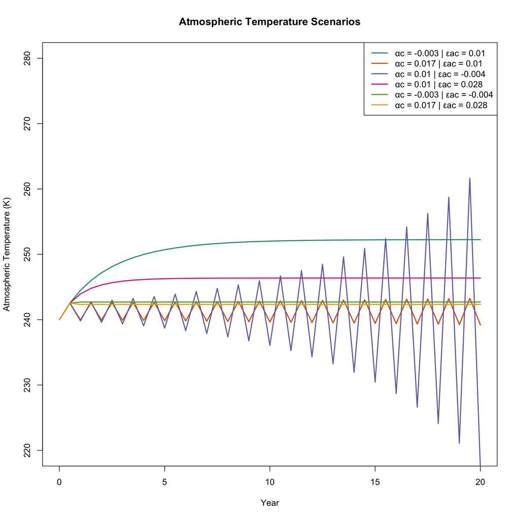

```r
params <- list(
  c(-0.003, 0.01), # low albedo var, normal emissivity var
  c(0.017, 0.01), # high albedo var, normal emissivity var
  c(0.01, -0.004), # normal albedo var, low emissivity var
  c(0.01, 0.028), # normal albedo var, high emissivity var
  c(-0.003, -0.004), # both low
  c(0.017, 0.028) # both high
)

library(RColorBrewer)
colors <- brewer.pal(n = 6, name = "Dark2")

#Ta
plot(NULL, xlim = c(0, 20), ylim = c(220, 280), xlab = "Year", ylab = "Atmospheric Temperature (K)", main = "Atmospheric Temperature Scenarios")

for (i in 1:length(params)) {
  res <- simulateClimateChange(alpha_c = params[[i]][1], eps_ac = params[[i]][2], plot_flag = FALSE)
  lines(res$year, res$Ta, col = colors[i], lwd = 2)
}
legend("topright", legend = sapply(params, function(x) paste("αc =",x[1],"| εac =",x[2])), col = colors, lwd = 2)
```

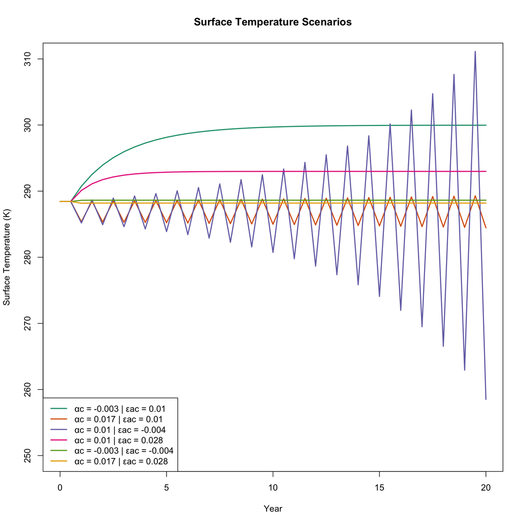

```r
#Ts
plot(NULL, xlim = c(0, 20), ylim = c(250, 310), xlab = "Year", ylab = "Surface Temperature (K)", main = "Surface Temperature Scenarios")

for (i in 1:length(params)) {
  res <- simulateClimateChange(alpha_c = params[[i]][1], eps_ac = params[[i]][2], plot_flag = FALSE)
  lines(res$year, res$Ts, col = colors[i], lwd = 2)
}

legend("bottomleft",
       legend = sapply(params, function(x) paste("αc =", x[1], "| εac =", x[2])), col = colors, lwd = 2)
```

5. By considering outcomes for the first and second experiments, describe the relative sensitivity of the temperatures to changes in each of the parameters. Sensitivity is a measure of how much change in the outcome occurs with change to the input value (e.g., zero change in outcome would indicate zero sensitivity). [1]

The model demonstrates that temperature is more sensitive to changes in emissivity than to albedo, with emissivity strongly influencing both the magnitude and stability of temperature evolution.

6. Create a table that summarizes outcomes for several variation coefficient values (albedo across the table, emissivity down), reporting the temperature asymptote value (if an asymptote occurs), otherwise describing the behavior of the temperature (including noting whether one or both parameters become invalid). Include the maximum/minimum values you found in #2 and #3, as well as 0.01 K-1 on each table axis, and insert an appropriate number of other values on each axis to demonstrate any patterns (aim for around seven values for each parameter). [2]

```r
alpha_values <- seq(-0.003, 0.017, length.out = 7)
eps_values <- seq(-0.004, 0.028, length.out = 7)

get_asymptote <- function(alpha_c, eps_ac) {
  res <- simulateClimateChange(alpha_c = alpha_c, eps_ac = eps_ac, plot_flag = FALSE)
  if (any(res$alpha < 0 | res$alpha > 1 | res$epsilon_a < 0 | res$epsilon_a > 1)) {
    return("invalid")
  }
  Ts_vals <- tail(res$Ts, 6)
  if (max(diff(Ts_vals)) < 0.01) {
    return(round(mean(Ts_vals), 2))
  } else {
    return("no asymptote")
  }
}

table6 <- matrix(NA, nrow = length(eps_values), ncol = length(alpha_values))
for (i in seq_along(eps_values)) {
  for (j in seq_along(alpha_values)) {
    table6[i, j] <- get_asymptote(alpha_values[j], eps_values[i])
  }
}

colnames(table6) <- paste("αc =", round(alpha_values, 4))
rownames(table6) <- paste("εac =", round(eps_values, 4))
table6
```

```
##              αc = -0.003 αc = 3e-04 αc = 0.0037 αc = 0.007 αc = 0.0103
## εac = -0.004 "288.63"    "287.87"   "287.4"     "287.08"   "invalid"
## εac = 0.0013 "289.89"    "288.55"   "287.82"    "287.37"   "287.06"
## εac = 0.0067 "292.94"    "289.77"   "288.48"    "287.77"   "287.33"
## εac = 0.012  "invalid"   "292.8"    "289.65"    "288.4"    "287.73"
## εac = 0.0173 "invalid"   "invalid"  "292.65"    "289.53"   "288.33"
## εac = 0.0227 "invalid"   "invalid"  "invalid"   "292.48"   "289.42"
## εac = 0.028  "invalid"   "invalid"  "invalid"   "invalid"  "292.3"
##              αc = 0.0137    αc = 0.017
## εac = -0.004 "invalid"      "invalid"
## εac = 0.0013 "invalid"      "invalid"
## εac = 0.0067 "no asymptote" "invalid"
## εac = 0.012  "287.3"        "no asymptote"
## εac = 0.0173 "287.68"       "287.27"
## εac = 0.0227 "288.26"       "287.63"
## εac = 0.028  "289.3"        "288.19"
```

```r
library(knitr)
library(kableExtra)

kable(table6, caption = "Q6: Asymptotic Surface Temperatures (K)",
      align = "c") %>%
  kable_styling(bootstrap_options = c("striped", "hover", "condensed", "bordered"),
                full_width = FALSE,
                position = "center",
                font_size = 12)
```

Q6: Asymptotic Surface Temperatures (K)

|  | αc = -0.003 | αc = 3e-04 | αc = 0.0037 | αc = 0.007 | αc = 0.0103 | αc = 0.0137 | αc = 0.017 |
| --- | --- | --- | --- | --- | --- | --- | --- |
| εac = -0.004 | 288.63 | 287.87 | 287.4 | 287.08 | invalid | invalid | invalid |
| εac = 0.0013 | 289.89 | 288.55 | 287.82 | 287.37 | 287.06 | invalid | invalid |
| εac = 0.0067 | 292.94 | 289.77 | 288.48 | 287.77 | 287.33 | no asymptote | invalid |
| εac = 0.012 | invalid | 292.8 | 289.65 | 288.4 | 287.73 | 287.3 | no asymptote |
| εac = 0.0173 | invalid | invalid | 292.65 | 289.53 | 288.33 | 287.68 | 287.27 |
| εac = 0.0227 | invalid | invalid | invalid | 292.48 | 289.42 | 288.26 | 287.63 |
| εac = 0.028 | invalid | invalid | invalid | invalid | 292.3 | 289.3 | 288.19 |

7. Comment on the plots (#4) and the range of variation coefficient values that produce valid outcomes (#6). [2]

PART B: In Equation 1, replace the atmospheric temperature, Ta, with surface temperature, Ts (including resetting the reference temperature to Ts0 = 288 K). 8. Redo steps #4-7 and describe the effect for various values of the variation coefficients. [4]

```r
simulateClimateChange1 <- function(alpha_c = 0.01, eps_ac = 0.01, plot_flag = TRUE) {
  A <- 4 * pi * (6378000^2) # earth surface area
  propn_ocean <- 0.7
  C <- (A * propn_ocean * 100 * 1025 * 3.993) + (A * (1 - propn_ocean) * 5 * 1600 * 0.8)

  S <- 1368
  sigma <- 5.6704e-8
  Ts0 <- 288
  alpha_0 <- 0.3
  eps_a0 <- 0.78

  time_int <- (365 / 2) * 24 * 60 * 60
  num_years <- 20
  year <- seq(from = 0, to = num_years, by = 0.5)

  rate_in <- rep(S / 4, length(year))
  rate_out <- numeric(length(year))
  delta_T <- numeric(length(year))
  Ts <- numeric(length(year))
  Ts[1] <- Ts0
  Ta <- numeric(length(year))
  Ta[1] <- Ts0 / (2 ^ 0.25)
  alpha <- numeric(length(year))
  alpha[1] <- alpha_0
  epsilon_a <- numeric(length(year))
  epsilon_a[1] <- eps_a0

  for (i in 2:length(year)) {
    epsilon_a[i] <- eps_ac * (Ts[i-1] - Ts0) + eps_a0
    alpha[i] <- alpha_c * (Ts[i-1] - Ts0) + alpha_0

    Ts[i] <- ((S * (1 - alpha[i])) / (4 * sigma * (1 - (epsilon_a[i] / 2)))) ^ 0.25
    Ta[i] <- Ts[i] / (2 ^ 0.25)
    rate_out[i] <- alpha[i] * S / 4 + (1 - epsilon_a[i]) * sigma * Ts[i]^4 + epsilon_a[i] * sigma * Ta[i]^4
    delta_T[i] <- (1 / C) * (rate_in[i] - rate_out[i]) * (A / 1000) * time_int

    if (i < length(year)) {
      Ts[i+1] <- Ts[i] + delta_T[i]
    }
  }

  ClimateChange1 <- data.frame(year, Ts, Ta, alpha, epsilon_a)

  if (plot_flag) {
    with(ClimateChange1, {
      plot(Ts ~ year, type = "l", col = "blue",
           ylim = c(min(Ta)-10, max(Ts)+10), ylab = "Temperature (K)",
           main = paste("alpha_c =", alpha_c, " | eps_ac =", eps_ac))
      lines(Ta ~ year, col = "red")
      legend("topright", c("Surface (Ts)", "Atmosphere (Ta)"), col = c("blue", "red"), lty = 1)
    })
  }

  return(ClimateChange1)
}
```

8-4. Replicate the plot in #1 for key parameter values that have interesting outcomes and that produce values at/near limits of the valid range of albedo and emissivity (see previous notes on valid ranges). You should aim to present 4-8 scenarios. Plot atmospheric temperature from all scenarios on a single plot (using different colours for each scenario) and surface temperature from all scenarios on a second plot (using matching colours). [2]

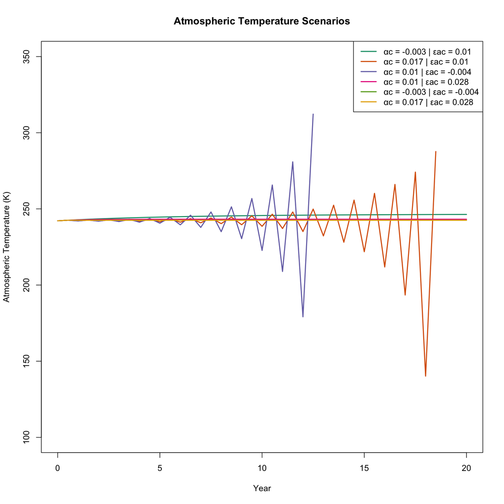

```r
params <- list(
  c(-0.003, 0.01),   # low albedo var, normal emissivity var
  c(0.017, 0.01),    # high albedo var, normal emissivity var
  c(0.01, -0.004),   # normal albedo var, low emissivity var
  c(0.01, 0.028),    # normal albedo var, high emissivity var
  c(-0.003, -0.004), # both low ends
  c(0.017, 0.028)    # both high ends
)

library(RColorBrewer)
colors <- brewer.pal(n = 6, name = "Dark2")

#Ta
plot(NULL, xlim = c(0, 20), ylim = c(100, 350),
     xlab = "Year", ylab = "Atmospheric Temperature (K)",
     main = "Atmospheric Temperature Scenarios")

for (i in 1:length(params)) {
  res <- simulateClimateChange1(alpha_c = params[[i]][1], eps_ac = params[[i]][2], plot_flag = FALSE)
  lines(res$year, res$Ta, col = colors[i], lwd = 2)
}
legend("topright", legend = sapply(params, function(x) paste("αc =",x[1],"| εac =",x[2])),
       col = colors, lwd = 2)
```

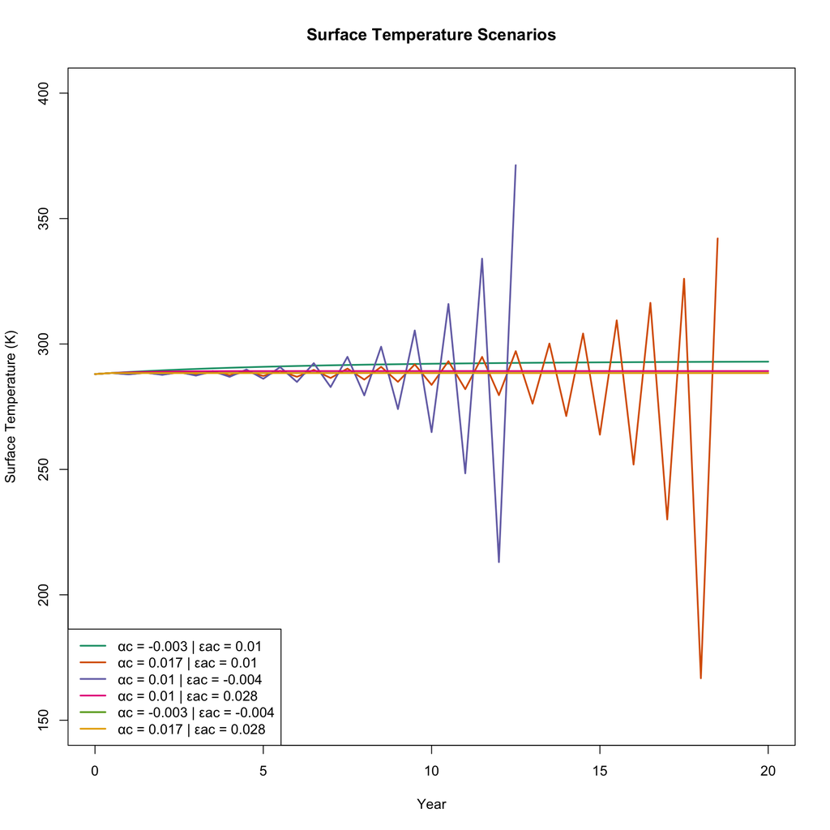

```r
#Ts
plot(NULL, xlim = c(0, 20), ylim = c(150, 400),
     xlab = "Year", ylab = "Surface Temperature (K)",
     main = "Surface Temperature Scenarios")

for (i in 1:length(params)) {
  res <- simulateClimateChange1(alpha_c = params[[i]][1],
                               eps_ac = params[[i]][2],
                               plot_flag = FALSE)
  lines(res$year, res$Ts, col = colors[i], lwd = 2)
}

legend("bottomleft",
       legend = sapply(params,
                       function(x) paste("αc =", x[1], "| εac =", x[2])),
       col = colors, lwd = 2)
```

8-5. By considering outcomes for the first and second experiments, describe the relative sensitivity of the temperatures to changes in each of the parameters. Sensitivity is a measure of how much change in the outcome occurs with change to the input value (e.g., zero change in outcome would indicate zero sensitivity). [1]

The model is much more sensitive to changes in emissivity variation, εac, than to changes in albedo variation, αc. Altering emissivity strongly affects both the magnitude and stability of temperature evolution, while albedo changes mainly influence oscillation behavior and have a smaller overall effect on equilibrium temperature.

8-6. Create a table that summarizes outcomes for several variation coefficient values (albedo across the table, emissivity down), reporting the temperature asymptote value (if an asymptote occurs), otherwise describing the behavior of the temperature (including noting whether one or both parameters become invalid). Include the maximum/minimum values you found in #2 and #3, as well as 0.01 K-1 on each table axis, and insert an appropriate number of other values on each axis to demonstrate any patterns (aim for around seven values for each parameter). [2]

```r
alpha_values <- seq(-0.003, 0.017, length.out = 7)
eps_values <- seq(-0.004, 0.028, length.out = 7)

get_asymptote <- function(alpha_c, eps_ac) {
  res <- simulateClimateChange1(alpha_c = alpha_c, eps_ac = eps_ac, plot_flag = FALSE)
  if (any(res$alpha < 0 | res$alpha > 1 | res$epsilon_a < 0 | res$epsilon_a > 1)) {
    return("invalid")
  }
  Ts_vals <- tail(res$Ts, 6)
  if (max(diff(Ts_vals)) < 0.01) {
    return(round(mean(Ts_vals), 2))
  } else {
    return("no_asymptote")
  }
}

table6 <- matrix(NA, nrow = length(eps_values), ncol = length(alpha_values))
for (i in seq_along(eps_values)) {
  for (j in seq_along(alpha_values)) {
    table6[i, j] <- get_asymptote(alpha_values[j], eps_values[i])
  }
}

colnames(table6) <- paste("αc =", round(alpha_values, 4))
rownames(table6) <- paste("εac =", round(eps_values, 4))
table6
```

```
##              αc = -0.003 αc = 3e-04 αc = 0.0037 αc = 0.007     αc = 0.0103
## εac = -0.004 "288.47"    "288.34"   "288.27"    "no_asymptote" "invalid"
## εac = 0.0013 "288.71"    "288.45"   "288.33"    "288.26"       "no_asymptote"
## εac = 0.0067 "289.47"    "288.68"   "288.44"    "288.33"       "288.26"
## εac = 0.012  "invalid"   "289.36"   "288.65"    "288.43"       "288.32"
## εac = 0.0173 "invalid"   "invalid"  "289.26"    "288.62"       "288.42"
## εac = 0.0227 "invalid"   "invalid"  "invalid"   "289.17"       "288.6"
## εac = 0.028  "invalid"   "invalid"  "invalid"   "invalid"      "289.09"
##              αc = 0.0137    αc = 0.017
## εac = -0.004 "invalid"      "invalid"
## εac = 0.0013 "invalid"      "invalid"
## εac = 0.0067 "no_asymptote" "invalid"
## εac = 0.012  "288.25"       "no_asymptote"
## εac = 0.0173 "288.31"       "288.25"
## εac = 0.0227 "288.41"       "288.31"
## εac = 0.028  "288.58"       "288.39"
```

```r
library(knitr)
library(kableExtra)

kable(table6, caption = "Q6: Asymptotic Surface Temperatures (K)",
      align = "c") %>%
  kable_styling(bootstrap_options = c("striped", "hover", "condensed", "bordered"),
                full_width = FALSE,
                position = "center",
                font_size = 12)
```

Q6: Asymptotic Surface Temperatures (K)

|  | αc = -0.003 | αc = 3e-04 | αc = 0.0037 | αc = 0.007 | αc = 0.0103 | αc = 0.0137 | αc = 0.017 |
| --- | --- | --- | --- | --- | --- | --- | --- |
| εac = -0.004 | 288.47 | 288.34 | 288.27 | no_asymptote | invalid | invalid | invalid |
| εac = 0.0013 | 288.71 | 288.45 | 288.33 | 288.26 | no_asymptote | invalid | invalid |
| εac = 0.0067 | 289.47 | 288.68 | 288.44 | 288.33 | 288.26 | no_asymptote | invalid |
| εac = 0.012 | invalid | 289.36 | 288.65 | 288.43 | 288.32 | 288.25 | no_asymptote |
| εac = 0.0173 | invalid | invalid | 289.26 | 288.62 | 288.42 | 288.31 | 288.25 |
| εac = 0.0227 | invalid | invalid | invalid | 289.17 | 288.6 | 288.41 | 288.31 |
| εac = 0.028 | invalid | invalid | invalid | invalid | 289.09 | 288.58 | 288.39 |

8-7. Comment on the plots (#4) and the range of variation coefficient values that produce valid outcomes (#6). [2]

PART C: Replace the linear function of Equation 1 with a non-linear form for emissivity. 9. Determine the value of k where εa = 0.78 at Ta = 240 K. Apply this constant value of k to determine the temperature evolution and describe the effect for various values of the albedo variation coefficient (i.e., repeat steps #4-7). [3]

```r
emissivity_s <- function(Ta) {
  6.11094 * exp((17.625 * (Ta - 273.15)) / (243.04 + (Ta - 273.15)))
}
k <- 0.78 / emissivity_s(240)
cat("k =", k, "\n")
```

```
## k = 2.065037
```

```r
simulateClimateChange_nonlinear <- function(alpha_c = 0.01, plot_flag = TRUE) {
  A <- 4 * pi * (6378000^2)
  propn_ocean <- 0.7
  C <- (A * propn_ocean * 100 * 1025 * 3.993) + (A * (1 - propn_ocean) * 5 * 1600 * 0.8)

  S <- 1368
  sigma <- 5.6704e-8
  Ta0 <- 240
  alpha_0 <- 0.3
  eps_a0 <- 0.78

  time_int <- (365 / 2) * 24 * 60 * 60
  num_years <- 20
  year <- seq(from = 0, to = num_years, by = 0.5)

  rate_in <- rep(S / 4, length(year))
  Ts <- numeric(length(year))
  Ta <- numeric(length(year))
  alpha <- numeric(length(year))
  epsilon_a <- numeric(length(year))

  Ts[1] <- ((S * (1 - alpha_0)) / (4 * sigma * (1 - (eps_a0 / 2)))) ^ 0.25
  Ta[1] <- Ta0
  alpha[1] <- alpha_0
  epsilon_a[1] <- eps_a0

  for (i in 2:length(year)) {
    epsilon_a[i] <- k * emissivity_s(Ta[i-1])
    alpha[i] <- alpha_c * (Ta[i-1] - Ta0) + alpha_0
    Ts[i] <- ((S * (1 - alpha[i])) / (4 * sigma * (1 - (epsilon_a[i] / 2)))) ^ 0.25
    Ta[i] <- Ts[i] / (2 ^ 0.25)
  }

  df <- data.frame(year, Ts, Ta, alpha, epsilon_a)
  if (plot_flag) {
    plot(df$year, df$Ts, type = "l", col = "blue",
         ylim = c(230, 320), xlab = "Year", ylab = "Temperature (K)",
         main = paste("Nonlinear emissivity | αc =", alpha_c))
    lines(df$year, df$Ta, col = "red")
    legend("topright", c("Surface (Ts)", "Atmosphere (Ta)"), col = c("blue", "red"), lty = 1)
  }
  return(df)
}
```

9-2. With emissivity variation constant (=0.01 K-1), determine the maximum and minimum values of the albedo variation coefficient for which valid values of albedo and emissivity occur. [1]

```r
alpha_values <- seq(0.048, 0.059, by = 0.001)
results_alpha <- list()

for (a in alpha_values) {
  cat("Running alpha_c =", a, "\n")
  res <- simulateClimateChange_nonlinear(alpha_c = a, plot_flag = FALSE)
  results_alpha[[as.character(a)]] <- res
}
```

```
## Running alpha_c = 0.048
## Running alpha_c = 0.049
## Running alpha_c = 0.05
## Running alpha_c = 0.051
## Running alpha_c = 0.052
## Running alpha_c = 0.053
## Running alpha_c = 0.054
## Running alpha_c = 0.055
## Running alpha_c = 0.056
## Running alpha_c = 0.057
## Running alpha_c = 0.058
## Running alpha_c = 0.059
```

```r
valid_alpha <- sapply(results_alpha, function(df) all(df$alpha >= 0 & df$alpha <= 1))
valid_eps <- sapply(results_alpha, function(df) all(df$epsilon_a >= 0 & df$epsilon_a <= 1))

data.frame(alpha_c = alpha_values, valid_alpha, valid_eps)
```

```
##       alpha_c valid_alpha valid_eps
## 0.048   0.048       FALSE     FALSE
## 0.049   0.049        TRUE      TRUE
## 0.05    0.050        TRUE      TRUE
## 0.051   0.051        TRUE      TRUE
## 0.052   0.052        TRUE      TRUE
## 0.053   0.053        TRUE      TRUE
## 0.054   0.054        TRUE      TRUE
## 0.055   0.055        TRUE      TRUE
## 0.056   0.056        TRUE      TRUE
## 0.057   0.057        TRUE      TRUE
## 0.058   0.058        TRUE      TRUE
## 0.059   0.059        TRUE     FALSE
```

The maximum and minimum values of the albedo variation coefficient for which valid values of albedo and emissivity occur are 0.058 and 0.049 respectively.

9-4. Replicate the plot in #1 for key parameter values that have interesting outcomes and that produce values at/near limits of the valid range of albedo and emissivity (see previous notes on valid ranges). You should aim to present 4-8 scenarios. Plot atmospheric temperature from all scenarios on a single plot (using different colours for each scenario) and surface temperature from all scenarios on a second plot (using matching colours). [2]

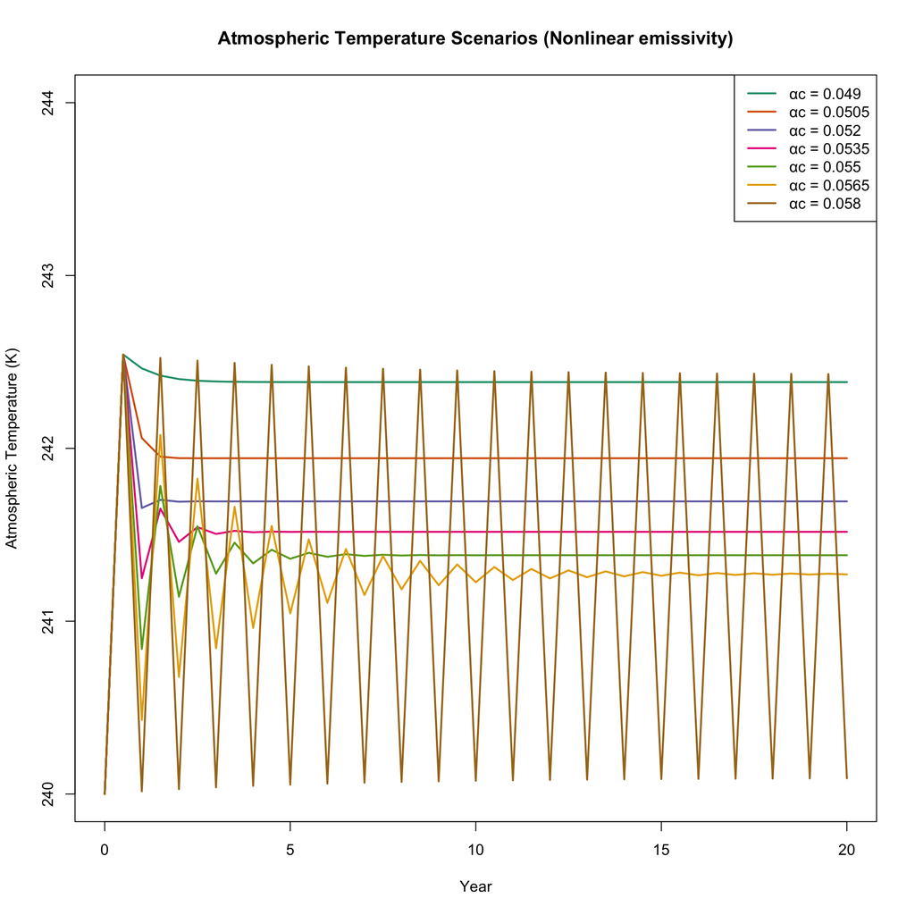

```r
alpha_vals <- seq(from = 0.049, to = 0.058, length.out = 7)

library(RColorBrewer)
colors <- brewer.pal(n = length(alpha_vals), name = "Dark2")

#Ta
plot(NULL, xlim = c(0, 20), ylim = c(240, 244), xlab = "Year", ylab = "Atmospheric Temperature (K)", main = "Atmospheric Temperature Scenarios (Nonlinear emissivity)")

for (i in seq_along(alpha_vals)) {
  res <- simulateClimateChange_nonlinear(alpha_c = alpha_vals[i], plot_flag = FALSE)
  lines(res$year, res$Ta, col = colors[i], lwd = 2)
}
legend("topright", legend = paste("αc =", alpha_vals), col = colors, lwd = 2)
```

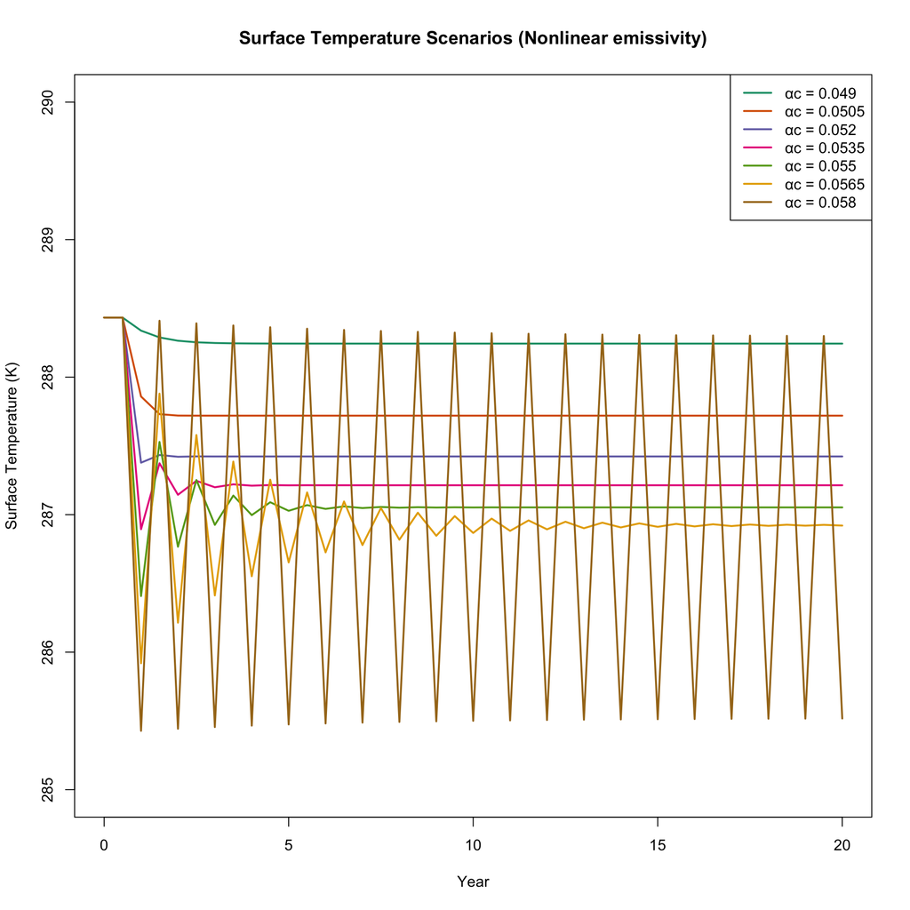

```r
#Ts
plot(NULL, xlim = c(0, 20), ylim = c(285, 290), xlab = "Year", ylab = "Surface Temperature (K)", main = "Surface Temperature Scenarios (Nonlinear emissivity)")

for (i in seq_along(alpha_vals)) {
  res <- simulateClimateChange_nonlinear(alpha_c = alpha_vals[i], plot_flag = FALSE)
  lines(res$year, res$Ts, col = colors[i], lwd = 2)
}
legend("topright", legend = paste("αc =", alpha_vals), col = colors, lwd = 2)
```

9-5. By considering outcomes for the first and second experiments, describe the relative sensitivity of the temperatures to changes in each of the parameters. Sensitivity is a measure of how much change in the outcome occurs with change to the input value (e.g., zero change in outcome would indicate zero sensitivity). [1]

The model shows moderate sensitivity to albedo variation, small changes in αc alter the amplitude and duration of oscillations but not the overall equilibrium temperature dramatically.

9-6. Create a table that summarizes outcomes for several variation coefficient values (albedo across the table, emissivity down), reporting the temperature asymptote value (if an asymptote occurs), otherwise describing the behavior of the temperature (including noting whether one or both parameters become invalid). Include the maximum/minimum values you found in #2 and #3, as well as 0.01 K-1 on each table axis, and insert an appropriate number of other values on each axis to demonstrate any patterns (aim for around seven values for each parameter). [2]

```r
alpha_values <- seq(0.049, 0.058, length.out = 7)

get_asymptote_nonlinear <- function(alpha_c) {
  res <- simulateClimateChange_nonlinear(alpha_c = alpha_c, plot_flag = FALSE)

  if (any(res$alpha < 0 | res$alpha > 1)) {
    return(c(Ts = NA, Ta = NA, behaviour = "invalid"))
  }

  Ts_vals <- tail(res$Ts, 6)
  Ta_vals <- tail(res$Ta, 6)

  if (max(diff(Ts_vals)) < 0.01) {
    return(c(Ts = round(mean(Ts_vals), 2), Ta = round(mean(Ta_vals), 2), behaviour = "asymptotic"))
  } else {
    return(c(Ts = NA, Ta = NA, behaviour = "no_asymptote"))
  }
}

results9 <- data.frame(alpha_c = alpha_values, Ts_asym = NA, Ta_asym = NA, Behaviour = NA)

for (i in seq_along(alpha_values)) {
  res <- get_asymptote_nonlinear(alpha_values[i])
  results9$Ts_asym[i] <- res["Ts"]
  results9$Ta_asym[i] <- res["Ta"]
  results9$Behaviour[i] <- res["behaviour"]
}

library(knitr)
library(kableExtra)

kable(results9, caption = "Q9: Asymptotic Temperatures for Nonlinear Model", align = "c") %>%
  kable_styling(bootstrap_options = c("striped", "hover", "condensed", "bordered"), full_width = FALSE, position = "center", font_size = 12)
```

Q9: Asymptotic Temperatures for Nonlinear Model

| alpha_c | Ts_asym | Ta_asym | Behaviour |
| --- | --- | --- | --- |
| 0.0490 | 288.24 | 242.38 | asymptotic |
| 0.0505 | 287.72 | 241.94 | asymptotic |
| 0.0520 | 287.42 | 241.69 | asymptotic |
| 0.0535 | 287.21 | 241.52 | asymptotic |
| 0.0550 | 287.05 | 241.38 | asymptotic |
| 0.0565 | 286.92 | 241.27 | asymptotic |
| 0.0580 | NA | NA | no_asymptote |

9-7. Comment on the plots (#4) and the range of variation coefficient values that produce valid outcomes (#6). [2]

From Question 4, for both atmospheric and surface temperatures, increasing the albedo variation coefficient, αc, from 0.049 to 0.0565 results in a gradual decrease in the equilibrium (asymptotic) temperatures and a slow emergence of oscillatory behavior. At αc = 0.049–0.052, the system reaches stable equilibrium quickly, with asymptotes around Ts ≈ 287.5–288.2 K and Ta ≈ 241.7–242.5 K. At αc = 0.0535–0.0565, small oscillations appear before stabilizing — oscillation amplitude increases from ~0.4 K, lasting 2–3 years, to ~2 K, lasting about 18 years. At αc = 0.058, oscillations become larger (~3 K) and persistent, with no stability within 20 years, suggesting the upper stability limit of the model. From Question 6, The model remains valid and convergent for 0.049 ≤ αc ≤ 0.0565, where both surface and atmospheric temperatures reach stable asymptotes. Beyond αc ≈ 0.058, the model becomes unstable, showing continuous oscillations and failing to achieve equilibrium within the 20-year simulation period. Within the valid range, surface temperature asymptotes decrease slightly (from 288.2 K to 286.9 K) as αc increases, while atmospheric temperatures follow a similar trend (from 242.4 K to 241.3 K). This demonstrates that the system’s equilibrium is sensitive but stable under small albedo variations. Overall, the valid outcomes occur in a narrow αc range, confirming that the model’s stability is tightly constrained and that increasing αc beyond ~0.057 leads to non-physical, oscillatory behavior.